# COMAP_FINAL_NOTEBOOK

<h1 align = "center"> Data Insights:  
Energy Consumption and Production in California, New Mexico, Texas and Arizona (1960 - 2009)</h1>

<h5 align = "center">February 13 2018 </h5>

Notebook author: Laura Gutierrez Funderburk

The functions, ideas and models presented in this notebook are joint work with Bryce Hayley

Problem C proposed by [© 2018 COMAP](http://www.comap-math.com/mcm/)

The problem in this notebook has been presented in the author's own words

<h3 align = "center"> Abstract </h3>

Energy production and consumption are a major component of any economy. On a national level, aspects of energy policy can be either centralized or descentralized. The geographical and industrial differences that exist within the same nation affect energy production and consumption.

One approach to this problem is forming an interstate compact, that is, a contractual agreement made between two or more entities whose goal is to agree on a specific policy issue and either adopt a set of standards or cooperate with one another.

<h3 align = "center"> Problem </h3>

In this notebook I will explore a particular instance of this problem. Consider the United States and the four states Californian, Arizona, New Mexico and Texas. They come together and wish to form a realistic new energy compact whose focus is to increase the use of cleaner, renewable energy sources. I am given 50 years (from 1960 to 2009) worth of data in 605 variables on each of the states' production and consumption, in addition to demographic and economic information.

<h3 align = "center"> Strategy </h3>

This problem can be seen from a game theoretic point of view, where each state is a player whose actions are either: cooperate, remain stagnant, apply internal policy change.

Step 1) With the data, create a profile for each state based on consumption and production on two levels: on a given year (2009 for example) and throughout the time frame 1960 - 2009.

Step 2) Model a score scheme that will allow to determine who the dominant and weak players are and apply scoring scheme on the levels described above.

Step 3) Use score to determine who dominant and weak players are over time.

Step 4) With the help of our model, predict in 2025 and 2050 where each state will go without policy change.

Step 5) Propose a policy change that prompts weak players to apply internal changes in their state, and dominant players to help weak players while they transition from fossil fuels to renewable energy sources.

```python
## Run scripts
%run -i data_handling.py
```

<h2 align = "center"> Energy Profile for each State </h2>

For each state, the following categories were selected.

#### Energy Consumption

Coal, Natural gas, Motor gasoline, Distillate fuel, Jet fuel, LGP, Residual fuel, Other petroleum, Biomass, Electricity

#### Energy Production

Coal, Natural gas, Crude oil, Nuclear power, Eolic, Solar, Hydroelectricity and Geothermal.

```python
# Calculate energy consumption for each state in 2009
cal_con = get_data_array(california,msn_array_con,-1)
newme_con = get_data_array(newmexico,msn_array_con,-1)
tex_con = get_data_array(texas,msn_array_con,-1)
ari_con = get_data_array(arizona,msn_array_con,-1)
```

```python
# Produced
cal_pro = get_data_array(california,msn_array_pro,-1)
newme_pro = get_data_array(newmexico,msn_array_pro,-1)
tex_pro = get_data_array(texas,msn_array_pro,-1)
ari_pro = get_data_array(arizona,msn_array_pro,-1)
```

<h3 align = "center"> California 2009 </h3>

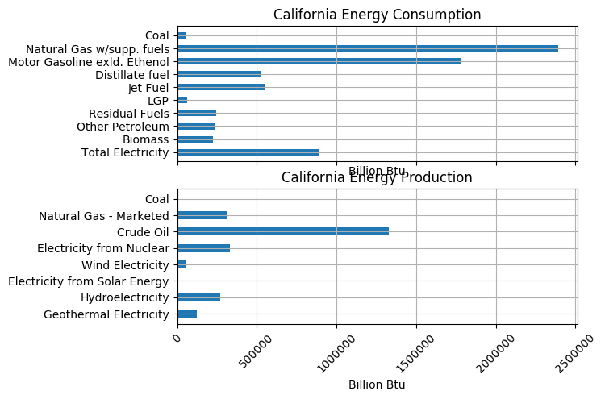

```python
plot_profile('California Energy Consumption',cal_con,energy_con,'California Energy Production',cal_pro,energy_pro)
```

#### Remarks

In 2009 California consumed coal the least (a few thousan billion Btu at most) and natural gas the most (2,500,000 billion Btu). Compared to natural gas, California's consumption of distilate fuel, jet fuel, LPG, biomass, residual fuels, electricity and other petroleum was not as significant.\ From the second chart we see that in 2009 California produced crude oil the most (over 1,300,000 billion Btu), virtually no coal, and produced electricity via greener and renewable sources such as wind, hydroelectricity and geothermal methods.

<h3 align = "center"> California 1960 - 2009</h3>

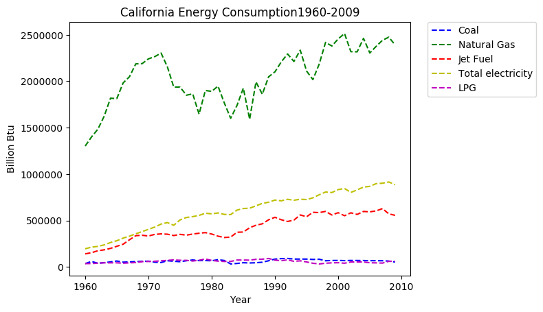

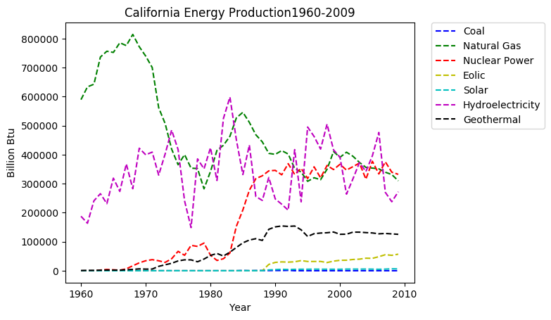

```python
plot_consumption_per_state(california,"California")
plot_electricity_production_per_state(california,"California")
```

#### Remarks

<h3 align = "center"> New Mexico 2009 </h3>

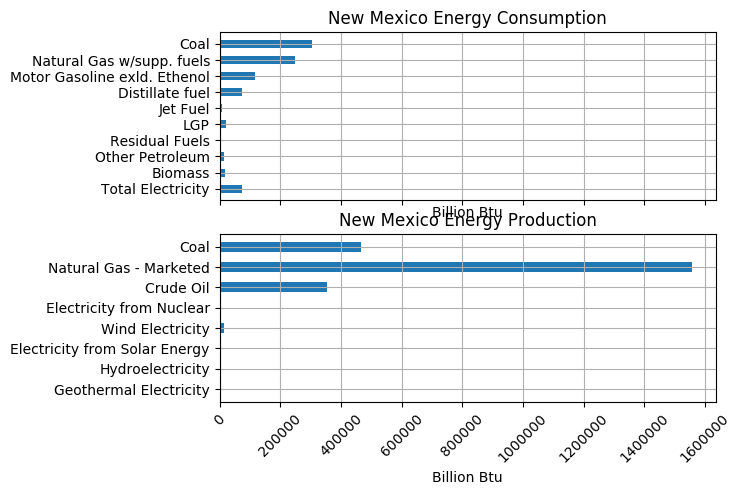

```python
plot_profile('New Mexico Energy Consumption',newme_con,energy_con,'New Mexico Energy Production',newme_pro,energy_pro)
```

#### Remarks

In 2009 New Mexico consumed coal the most, with over a whopping 300,000 billion Btu. There is virtually no use of residual fuels. Similarly, we see that in 2009 New Mexico produced the most natural gas (almost 1,600,000 billion Btu), followed by coal (over 400,000 billion Btu), crude oil (almost 400,000 billion Btu), wind electricity (a few thousand billion Btus at most) and no other energy source.

<h3 align = "center"> New Mexico 1960 - 2009 </h3>

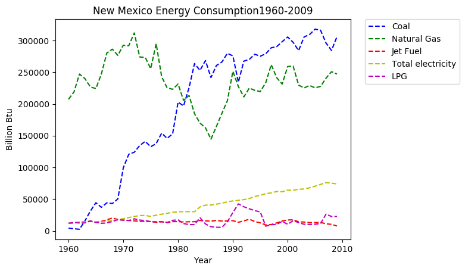

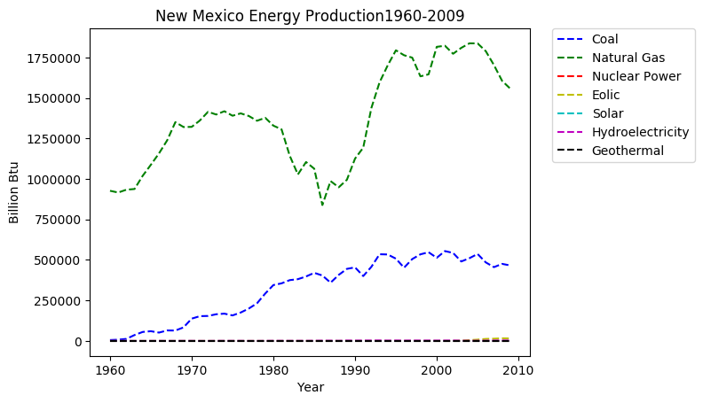

```python
plot_consumption_per_state(newmexico,'New Mexico')
plot_electricity_production_per_state(newmexico,"New Mexico")
```

#### Remarks

<h3 align = "center"> Texas 2009 </h3>

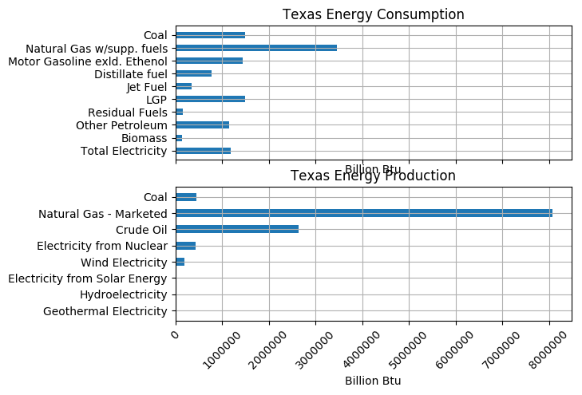

```python
plot_profile('Texas Energy Consumption',tex_con,energy_con,'Texas Energy Production',tex_pro,energy_pro)
```

#### Remarks

<h3 align = "center"> Texas 1960 - 2009 </h3>

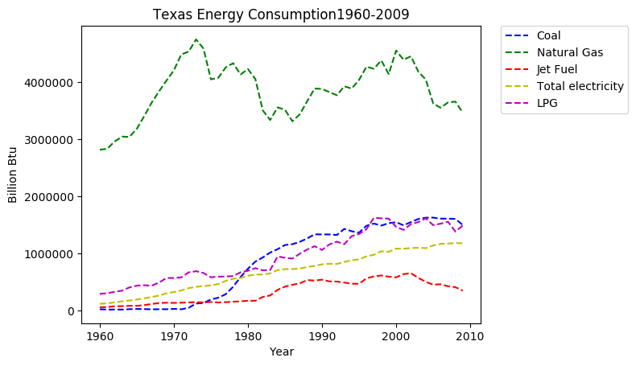

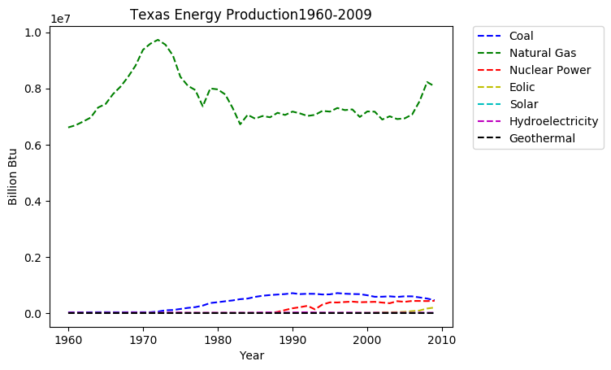

```python
plot_consumption_per_state(texas,"Texas")
plot_electricity_production_per_state(texas,"Texas")
```

#### Remarks

<h3 align = "center"> Arizona 2009 </h3>

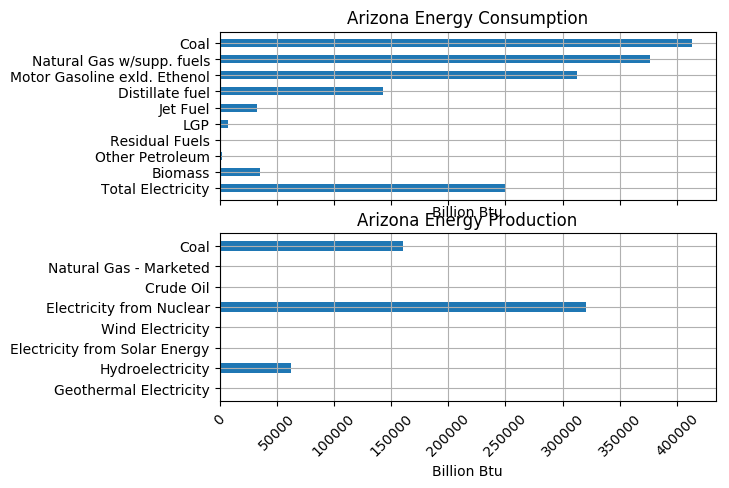

```python
plot_profile('Arizona Energy Consumption',ari_con,energy_con,'Arizona Energy Production',ari_pro,energy_pro)
```

#### Remarks

In 2009 Arizona consumed coal the most with (over 400,000 billion Btu), followed by natural gas (over 375,00 billion Btu), motor gasoline (over 300,000 billion Btu) and electricity (up to 250,000 billion Btu). We noticed immediately how Arizona produced electricity from nuclear power the most in 2009, followed by coal and hydroelectricity. Since Arizona consumed more coal than it produced this seems to suggest that importation took place.

<h3 align = "center"> Arizona 1960 - 2009 </h3>

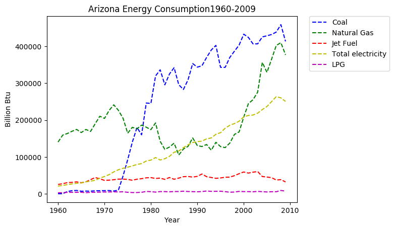

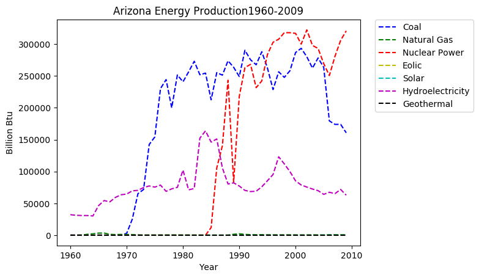

```python
plot_consumption_per_state(arizona,'Arizona')
plot_electricity_production_per_state(arizona,"Arizona")
```

#### Remarks

<h2 align = "center"> Scoring Scheme </h2>

The determination of best and wost preforming states was done by looking at the energy consumption in each state and examining the carbon output of larger fossil fuel categories. The specific categories of fossil fuel consumption are: Coal, Distillate, Motor Fuels, Jet Fuels, LPG, and Natural Gas. For this model we only considered consumption of fossil fuels. Production of energy was not considered in this scoring to not punish a state for producing the "dirty" energy used by another and too not overly punish a state for what has become an, unfortunate and immediate, economic necessity.

We model the scoring scheme as follows.

Let $S$ denote score for a given state, $C$ (units of $CO_2$ per billion Btu) the amount of carbon diaxoide emissions (see table below), $D$ (in billion Btu) the amount of fossil fuels consumed, and $P$ the total population$^{[1]}$. For reading purposes, we divide the score by 1000 and round to the nearest tenth, although we did not perform such computation on the data.

$$S = \dfrac{D \times C}{P}$$

We consider lower scores preferable over higher ones, as they indicate a lower consumption of $CO_2$ per person.

The values of $C$ were based on the table $^{[2]}$ below:

| Fuel Type | C (units of $CO_2$ per Million Btu) |
| --- | --- |
| Coal | 95.35 |
| Natural Gas | 53.07 |
| Motor Gasoline | 71.30 |
| Distillate | 73.16 |
| Jet Fuel | 70.9 |
| Propane/LGP & | 3.07 |
| Residual | 68.79 |

The values of $D$ were obtained from the data provided by COMAP and based on our selection of variables, while the populations were obtained from $[1]$.

We will compute the score for California, New Mexico,Texas and Arizona for 2009. We will then perform a similar calculation for 1960-2009 and plot their scores over time.

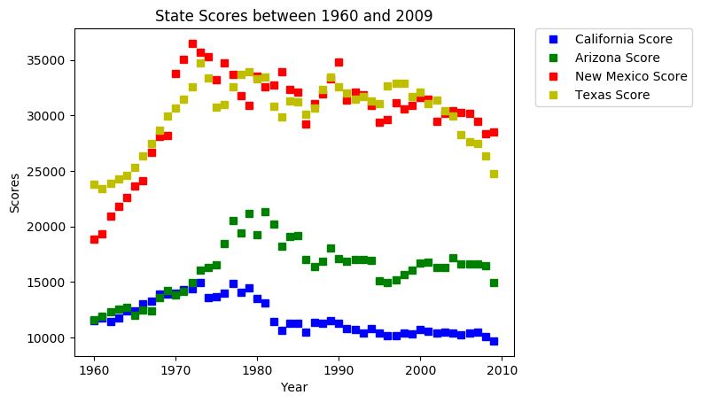

```python
plot_scores()
```

<h2 align ="center">Remarks</h2>

#### Scores for 2009

We summarize the scores for each state in 2009 in the following table. Recall that we consider lower scores to be preferable .

[output not shown]

We identify California and Arizona as dominant players and Texas and New Mexico as weak ones. This information will be useful to determine which states take over the role of supporter while weak players transition from fossil fuels to green and renewable energy.

#### Scores for 1960 - 2009

In order to truly get a full picture of who has been dominant and weak over time, we take a look at the trends taking place between 1960 and 2009 in the plot above.

<h2 align = "center">Predictions for 2025 and 2050 without change</h2>

We will use the scoring data between 1960 and 2009 and through the method of least squares$^{[3]}$ we propose the following system of equations. Let $y_{AZ},y_{CA},y_{NM},y_{TX}$ denote, respectively, the score of Arizona, California, New Mexico and Texas and x denote the year. We can then approximate the above scores as follows.

$$y_{AZ} = -18.3x + 52913$$$$y_{CA} = -43.96x + 98358$$$$y_{NM} = -144x + 318905$$$$y_{TX} = -213x + 455863$$

If we use our system of linear equations, we then predict the following outcomes in 2025 and 2050:

| State | Predicted Score 2025 | Predicted Score 2050 |  |
| --- | --- | --- | --- |
| California | 9.3 | 8.2 |  |
| Arizona | 15.9 | 15.4 |  |
| New Mexico | 27.3 | 23.7 |  |
| Texas | 24.5 | 19.2 |  |

We see little improvement in New Mexico and Texas and with this prediction there still exists a huge discrepancy between California,Arizona, New Mexico and Texas. This strongly suggests a policy change must be implemented.

<h2 align = "center">Proposed Lines of Action</h2>

We propose the following three lines of action.

### Carbon tax

A Carbon tax is a system of taxation placed on the purchase of fuel or energy that has carbon emission attached to it. By increasing the cost of carbon intensive energy forms, the tax attempts to influence purchasing decisions in favour of "greener" forms of energy. The effectiveness of this tax to influence purchasing decisions is influenced heavily by the availability of "greener" alternatives, but the tax could help to stimulate the development of such a market as well.

For the objective of improving the score defined in this paper the Tax would be on kg of carbon produced per BTU of fuel burned as defined the the U.S. Energy Information Agency.

### Strong Helps Weak

Implement a policy which allows strong states to support weak ones during the transition period. Policies may include exchange of credits and/or goods.

### Cap and Trade

This is a more complicated system then a straight carbon tax, but in other ways more direct. Cap and Trade sets a cap on carbon emissions for industry or for the economy. The government then distributes credits to companies that allow them to emit $CO_2$ up to the limit of their credit. To go above that a company would need to buy carbon credits on the open market from another company that has not used all theirs, risk paying a hefty fine for being in breach of the law, or cease operations in order to comply with the law and not emit any more $CO_2$.

<h2 align = "center">Conclusions and Open Questions</h2>

With the proposed scoring scheme, we determined that California and Arizona have taken the lead on consumotion of green and renewable sources of energy, while New Mexico and Texas are still producing huge quantities of $CO_2$ per person.

It is strongly advised that New Mexico and Texas implement internal caps on fossil fuel usage. To lessen the economical blow that this transition implies, we advise California and Arizona to aid the former states either via trading or the creationg of a new policy that will allow NM and TX to move towards the desired goal without compromising their economy in the process.

Open questions include, measuring error of scoring scheme. Our model does not take into account economical aspects related to industry in each country, but rather focused on carbon diaoxide.

<h2 align = "center">References</h2>

$[1]$ [EIA Government Website US Resident Population Estimates by State](https://www.eia.gov/state/seds/sep_use/notes/use_c.pdf)

$[2]$ [EIA Goverment Website. Carbon Dioxide Emissions Coefficients](https://www.eia.gov/environment/emissions/co2_vol_mass.php)

$[3]$ Blanchet et al., "Digital Signal and Image Processing using MATLAB", pp 389-450, 2013 London, UK: ISTE.